# Data Mining - Clustering

Andrew Esch, Evan Lee, and Collin Stratton

2-13-2022

# Introduction

# Part 1

Clustering is a collection of data points aggregated into similar groups. When using k-means clustering, the user will specify the number of clusters they want to create, or rather the number of centroids. The algorithm will then assign each data point to the closest cluster using the in-cluster sum of squares. The goal of clustering is to group similar data points and discover relationships from the clusters. It is advantageous to use because it is relatively time-efficient and can easily visualize the data. Its disadvantages are that it requires centroids to be inputted prior, so it doesn’t generate the most optimal number of clusters automatically, and it cannot handle noisy data and outliers. An example of clustering will be further explored in part 2.

Association Rule Mining is the process of finding patterns in data that can be used to predict the next event. If event A were to occur, how likely would event B occur? Using an example of finding the most commonly purchased grocery store items, the association is found by creating a list of all combinations of items purchased together. These combinations are used to find a confidence value for if item A is purchased, then item B will be purchased. This is very useful for places like grocery stores because they can use the data to organize their products to provide a better customer experience. Some drawbacks of association rule mining are that data collection is difficult due to the unique nature of text needed in the data, it can discover a huge number of rules or patterns that ultimately mean nothing, and the larger the dataset, the slower the algorithm. An example of association rule mining will be further explored in part 2.

# Kmeans clustering

Note: This may take some time to compile and run.

## Get data and libraries

```r
# General
library(readr)
library(ggplot2)
library(rlang)

# K-Means Clustering
library(factoextra)
library(stats)
library(ClusterR)

# Association Rules Mining
library(arules)
library(arulesViz)
library(dplyr)
library(DT)
```

### K-Means Clustering Data

```r
# Evan's CWD -> C:/Users/Evan/OneDrive/Documents/GitHub/CST-425/Clustering/online_shoppers_intention.csv
# Andrew's CWD -> C:/Users/andre/Documents/GitHub/CST-425/Clustering/online_shoppers_intention.csv
kmeansdf <- read.csv("C:/Users/andre/Documents/GitHub/CST-425/Clustering/online_shoppers_intention.csv")
kmeansdf <- data.frame(kmeansdf)
head(kmeansdf)
```

|  | Administrative | Administrative_Duration | Informational | Informational_Duration | ProductRelated | ProductRelated_Duration | BounceRates | ExitRates | PageValues | SpecialDay | Month | OperatingSystems | Browser | Region | TrafficType | VisitorType | Weekend | Revenue |
| --- | --- | --- | --- | --- | --- | --- | --- | --- | --- | --- | --- | --- | --- | --- | --- | --- | --- | --- |
| 1 | 0 | 0 | 0 | 0 | 1 | 0.000000 | 0.20000000 | 0.2000000 | 0 | 0 | Feb | 1 | 1 | 1 | 1 | Returning_Visitor | FALSE | FALSE |
| 2 | 0 | 0 | 0 | 0 | 2 | 64.000000 | 0.00000000 | 0.1000000 | 0 | 0 | Feb | 2 | 2 | 1 | 2 | Returning_Visitor | FALSE | FALSE |
| 3 | 0 | 0 | 0 | 0 | 1 | 0.000000 | 0.20000000 | 0.2000000 | 0 | 0 | Feb | 4 | 1 | 9 | 3 | Returning_Visitor | FALSE | FALSE |
| 4 | 0 | 0 | 0 | 0 | 2 | 2.666667 | 0.05000000 | 0.1400000 | 0 | 0 | Feb | 3 | 2 | 2 | 4 | Returning_Visitor | FALSE | FALSE |
| 5 | 0 | 0 | 0 | 0 | 10 | 627.500000 | 0.02000000 | 0.0500000 | 0 | 0 | Feb | 3 | 3 | 1 | 4 | Returning_Visitor | TRUE | FALSE |
| 6 | 0 | 0 | 0 | 0 | 19 | 154.216667 | 0.01578947 | 0.0245614 | 0 | 0 | Feb | 2 | 2 | 1 | 3 | Returning_Visitor | FALSE | FALSE |

### Association Rules Mining Data

## (K-Means): Pre-processing Data

### Normalizing Data for KMeans is useful since the algorithm calculates the different clusters based on distance.

```r
# Data cleaning
#head(kmeansdf)
scalecolumns <- c(5,7,8,9,10,12,13,14,15) # picks integer columns we want to scale
kmeansdf <- kmeansdf[,scalecolumns]
kmeansdf <- scale(kmeansdf)
head(kmeansdf)
```

```
     ProductRelated BounceRates  ExitRates PageValues SpecialDay
[1,]     -0.6909752  3.66704008  3.2291846  -0.317165 -0.3088088
[2,]     -0.6684909 -0.45766444  1.1714250  -0.317165 -0.3088088
[3,]     -0.6909752  3.66704008  3.2291846  -0.317165 -0.3088088
[4,]     -0.6684909  0.57351169  1.9945289  -0.317165 -0.3088088
[5,]     -0.4886166 -0.04519398  0.1425452  -0.317165 -0.3088088
[6,]     -0.2862580 -0.13202986 -0.3809200  -0.317165 -0.3088088
     OperatingSystems    Browser     Region TrafficType
[1,]       -1.2333763 -0.7902608 -0.8941422 -0.76259811
[2,]       -0.1360728 -0.2079435 -0.8941422 -0.51416134
[3,]        2.0585344 -0.7902608  2.4369825 -0.26572458
[4,]        0.9612308 -0.2079435 -0.4777516 -0.01728781
[5,]        0.9612308  0.3743739 -0.8941422 -0.01728781
[6,]       -0.1360728 -0.2079435 -0.8941422 -0.26572458
```

```r
print(sum(is.na(kmeansdf))) # Do not need to omit missing values because there are none
```

```
[1] 0
```

```r
#kmeansdf <- na.omit(kmeansdf) # Get rid of missing values (if any)

kmeansdf <- scale(kmeansdf) # Scale columns proportionately
```

## (K-Means): Build the model

### Decide number of groups using the elbow method

#### The greatest bend in the elbow graph will determine the optimal number of clusters that the kmeans algorithm will use. After the bend, there will be diminishing returns on the addition of more groupings.

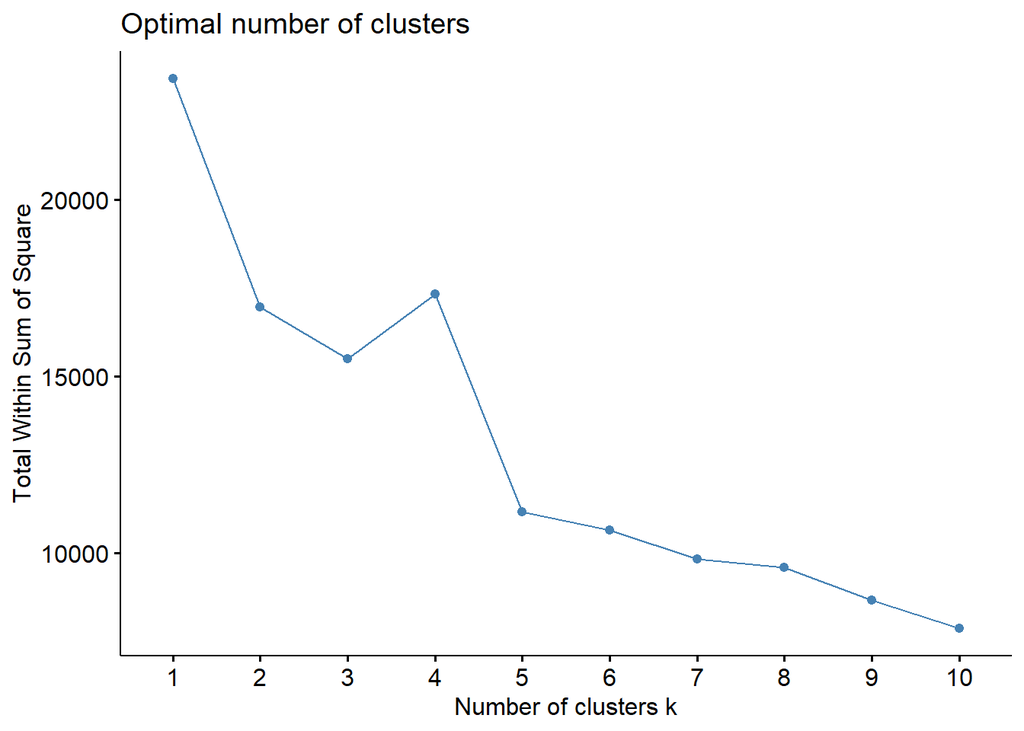

```r
set.seed(123)
kmeansdf2 <- kmeansdf
kmeansdf <- kmeansdf[1:3000,]
kmeansdf <- data.frame(kmeansdf)
fviz_nbclust(kmeansdf, kmeans, method = "wss")
```

### Build the model using optimal number of groups and show the results

```r
kmeansmodel <- kmeans(kmeansdf2, centers = 2, nstart = 25)
str(kmeansmodel)
```

```
List of 9
 $ cluster     : int [1:12330] 2 1 2 2 1 1 2 2 1 1 ...
 $ centers     : num [1:2, 1:9] 0.0606 -0.6428 -0.2785 2.9545 -0.2649 ...
  ..- attr(*, "dimnames")=List of 2
  .. ..$ : chr [1:2] "1" "2"
  .. ..$ : chr [1:9] "ProductRelated" "BounceRates" "ExitRates" "PageValues" ...
 $ totss       : num 110961
 $ withinss    : num [1:2] 82198 8694
 $ tot.withinss: num 90892
 $ betweenss   : num 20069
 $ size        : int [1:2] 11268 1062
 $ iter        : int 1
 $ ifault      : int 0
 - attr(*, "class")= chr "kmeans"
```

## (K-Means): Display the results (quantitative and visual)

### For our visualization of kmeans we use fviz_cluster(). From the results of fviz_cluster(), there are two groups, red and blue. We used 2 groupings from the elbow graph results. To make a better vizualization, next time we would get rid of outliers. We tried using three methods and multiple different resources but they all didn’t work for getting rid of outliers on our data. If given more time we would get rid of the outliers using either the zscore or IQR method. To get this method to work, we would use the following R code:

```r
# Quantitative Results
head(kmeansmodel)
```

[output not shown]

[output cut: 349 more lines]

```r
head(kmeansdf2)
```

```
     ProductRelated BounceRates  ExitRates PageValues SpecialDay
[1,]     -0.6909752  3.66704008  3.2291846  -0.317165 -0.3088088
[2,]     -0.6684909 -0.45766444  1.1714250  -0.317165 -0.3088088
[3,]     -0.6909752  3.66704008  3.2291846  -0.317165 -0.3088088
[4,]     -0.6684909  0.57351169  1.9945289  -0.317165 -0.3088088
[5,]     -0.4886166 -0.04519398  0.1425452  -0.317165 -0.3088088
[6,]     -0.2862580 -0.13202986 -0.3809200  -0.317165 -0.3088088
     OperatingSystems    Browser     Region TrafficType
[1,]       -1.2333763 -0.7902608 -0.8941422 -0.76259811
[2,]       -0.1360728 -0.2079435 -0.8941422 -0.51416134
[3,]        2.0585344 -0.7902608  2.4369825 -0.26572458
[4,]        0.9612308 -0.2079435 -0.4777516 -0.01728781
[5,]        0.9612308  0.3743739 -0.8941422 -0.01728781
[6,]       -0.1360728 -0.2079435 -0.8941422 -0.26572458
```

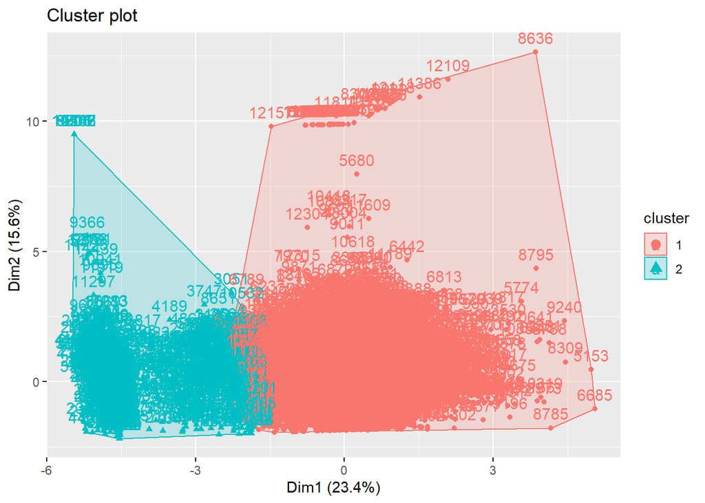

```r
# Visual Results
fviz_cluster(kmeansmodel, data = kmeansdf2)
```

## Cluster Analysis using aggregate and predict functions

```r
#find means of each cluster

aggregate(kmeansdf2, by=list(cluster=kmeansmodel$cluster), mean)
```

| cluster | ProductRelated | BounceRates | ExitRates | PageValues | SpecialDay | OperatingSystems | Browser | Region | TrafficType |
| --- | --- | --- | --- | --- | --- | --- | --- | --- | --- |
| 1 | 0.0605843 | -0.2784587 | -0.264872 | 0.02989255 | -0.0238976 | -0.005872649 | 0.002389449 | 0.003344307 | -0.02286596 |
| 2 | -0.6428097 | 2.9544942 | 2.810337 | -0.31716498 | 0.2535576 | 0.062309805 | -0.025352461 | -0.035483665 | 0.24261166 |

```r
testdata <- data.frame(ProductRelated=c(.05,.5),BounceRates=c(0,2),ExitRates=c(0,3),PageValues=c(0.75,0.1),SpecialDay=c(0,0),OperatingSystems=c(0.2,0.2),Browser=c(0.01,3),Region=c(0.2,0),TrafficType=c(0.35,0.8))
print("Prediction of test data 1:")
```

```
[1] "Prediction of test data 1:"
```

```r
predict_KMeans(testdata[1,],kmeansmodel$centers, threads=1)
```

```
[1] 1
```

```r
print("Prediction of test data 2:")
```

```
[1] "Prediction of test data 2:"
```

```r
predict_KMeans(testdata[2,],kmeansmodel$centers, threads=1)
```

```
[1] 2
```

### Predictions-

As a test, two artificial data points were made that follow the trends shown in the averaging to see if the kmeans model could predict which cluster each point will be part of. The first point made is made to resemble cluster 1 and the second point cluster 2. When using ClusterR’s function predict_KMeans() we can select each point with the cluster centers to figure out which point is closer to each center to predict the cluster it belongs to. When printed out the predict function correctly guesses the intended clustering of both points.

## Steps 6-7 (K-Means): Interpret the results and adjust your clustering

For KMeans, the calculation is taken from a distance equation from each of the variables for each instance. This means that all non-integer values will need to be changed into integer values if possible or ignored. Another part of the cleaning process was normalizing the variables so that they are all scaled uniformly so that outliers do not cause as big of a disruption. From our first calculation of the elbow graph, the optimal grouping for our KMeans k value is 2. This will split the data into two different groups. kmeans() is used to calculate the kmean model while fvis_cluster() will be used to visualize the kmeans model.

#——————————————————————————————————

# Association Rules Mining

To perform association rules mining, this section will analyze transactions from ecommerce data and create rules to predict highly-likely items (RHS) in an ecommerce basket to pair with a set of items in an online checkout basket (LHS list).

## Step 1: Importing Data

```r
# Evan's CWD -> C:/Users/Evan/OneDrive/Documents/GitHub/CST-425/Clustering/Store_Hackathon_Ideal_Data.csv
# Andrew's CWD -> C:/Users/andre/Documents/GitHub/CST-425/Clustering/ecommerce-data-final.csv
associationdf <- read.transactions("C:/Users/andre/Documents/GitHub/CST-425/Clustering/ecommerce-data-final.csv", format="basket", sep=',')
head(associationdf)
```

```
transactions in sparse format with
 6 transactions (rows) and
 34629 items (columns)
```

## Step 2 (Association Rules Mining): Pre-processing Data

### Format Data

Pre-processing the ecommerce data for conversion into a transaction list requires an appropriate dataset that comes formatted as a list of transactions (associated with a single ID) in one CSV file. This analysis took several approaches to accomplish successful data pre-processing.

In the start of this analysis, the “Store_Hackathon_Ideal_Data.csv” dataset was utilized due to the simplistic itemized dataset. However, this dataset is unable to be processed into a transactions list due to single items being associated with individual IDs. Consequently, this dataset is unusable for association rules mining.

To resolve these issues, we used Excel with a new dataset (see “data.csv”). This ecommerce data lists multiple items by ID. However, this data still displays items individually by row. Using Excel and Matrix transposing, we created a final .csv dataset that combines all transaction items into one row by ID (see “ecommerce-data-final.csv”).

### Remove Empty Transactions, if possible

```r
sum(is.na(associationdf))
```

```
[1] 0
```

```r
associationdf <- na.omit(associationdf)
```

After creating the dataset as a transactions list, it automatically removed transactions and prevented omitting other transactions. Combining this result with the formatted .csv data (from Excel editing), the ecommerce transaction data is ready to be turned into an association rules mining model.

### Step 3 (Association Rules Mining): Inspect and build the model to show model results

### Inspect frequent items in the transaction dataset

```r
frequentItems <- eclat(associationdf, parameter = list(supp = 0.05, maxlen = 15)) # Calculates the support with max length of 15 items
```

```
Eclat

parameter specification:
 tidLists support minlen maxlen            target  ext
    FALSE    0.05      1     15 frequent itemsets TRUE

algorithmic control:
 sparse sort verbose
      7   -2    TRUE

Absolute minimum support count: 1295

create itemset ...
set transactions ...[34629 item(s), 25902 transaction(s)] done [0.44s].
sorting and recoding items ... [5 item(s)] done [0.00s].
creating sparse bit matrix ... [5 row(s), 25902 column(s)] done [0.00s].
writing  ... [5 set(s)] done [0.00s].
Creating S4 object  ... done [0.00s].
```

```r
inspect(frequentItems)
```

```
    items                                support    count
[1] {WHITE HANGING HEART T-LIGHT HOLDER} 0.07555401 1957
[2] {JUMBO BAG RED RETROSPOT}            0.06810285 1764
[3] {LUNCH BAG RED RETROSPOT}            0.05269863 1365
[4] {REGENCY CAKESTAND 3 TIER}           0.06706046 1737
[5] {PARTY BUNTING}                      0.05675237 1470
```

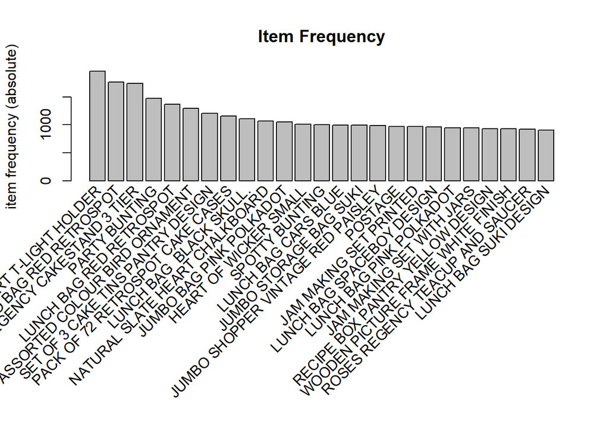

```r
itemFrequencyPlot(associationdf, topN=25, type="absolute", main="Item Frequency") # Plot the top 25 items
```

### Build the model and show result of rules creation

```r
# Use apriori to create the rules
# Bounds: Minimum support must be 0.005; Minimum confidence as 0.6 to sort out important transaction rules.
rules <- apriori(associationdf, parameter = list(supp = 0.005, conf = 0.6))
```

```
Apriori

Parameter specification:
 confidence minval smax arem  aval originalSupport maxtime support minlen
        0.6    0.1    1 none FALSE            TRUE       5   0.005      1
 maxlen target  ext
     10  rules TRUE

Algorithmic control:
 filter tree heap memopt load sort verbose
    0.1 TRUE TRUE  FALSE TRUE    2    TRUE

Absolute minimum support count: 129

set item appearances ...[0 item(s)] done [0.00s].
set transactions ...[34629 item(s), 25902 transaction(s)] done [0.41s].
sorting and recoding items ... [985 item(s)] done [0.01s].
creating transaction tree ... done [0.01s].
checking subsets of size 1 2 3 4 5 6 done [0.06s].
writing ... [903 rule(s)] done [0.00s].
creating S4 object  ... done [0.01s].
```

```r
# Show model summary
summary(rules)
```

```
set of 903 rules

rule length distribution (lhs + rhs):sizes
  2   3   4   5   6
137 476 244  40   6

   Min. 1st Qu.  Median    Mean 3rd Qu.    Max.
  2.000   3.000   3.000   3.227   4.000   6.000

summary of quality measures:
    support           confidence        coverage             lift
 Min.   :0.005019   Min.   :0.6000   Min.   :0.005212   Min.   :  8.563
 1st Qu.:0.005444   1st Qu.:0.6538   1st Qu.:0.006988   1st Qu.: 16.555
 Median :0.005945   Median :0.7192   Median :0.008223   Median : 24.262
 Mean   :0.006694   Mean   :0.7545   Mean   :0.009109   Mean   : 46.200
 3rd Qu.:0.006891   3rd Qu.:0.8602   3rd Qu.:0.009729   3rd Qu.: 71.552
 Max.   :0.025442   Max.   :1.0000   Max.   :0.040499   Max.   :129.568
     count
 Min.   :130.0
 1st Qu.:141.0
 Median :154.0
 Mean   :173.4
 3rd Qu.:178.5
 Max.   :659.0

mining info:
          data ntransactions support confidence
 associationdf         25902   0.005        0.6
                                                                      call
 apriori(data = associationdf, parameter = list(supp = 0.005, conf = 0.6))
```

The apriori library utilized association rules mining to create 903 rules with a support of 0.005 and a confidence of 0.6. The median metrics are: Support = 0.005945, Confidence: 0.7192, Coverage = 0.008223, lift = 24.262

## Step 4 (Association Rules Mining): Make predictions using a verified model

### Verify model using two measures

```r
# Measure 1: Coverage
# Goal: Test to ensure the proportion of transactions is not overly centralized on a small set of transactions
# Measures the probability that a rule applies to transactions selected at random
coverage <- interestMeasure(rules, measure="Coverage", transactions=associationdf)
summary(coverage)
```

```
    Min.  1st Qu.   Median     Mean  3rd Qu.     Max.
0.005212 0.006988 0.008223 0.009109 0.009729 0.040499
```

```r
# Measure 2: Fisher's Exact Test
# Goal: Find the proportion of extreme rules that go beyond the calculated test statistic
# Measures the percentage of rules that go beyond the test statistic, calculated using a p-value.
fisherTest <- interestMeasure(rules, measure="fishersExactTest", transactions=associationdf)
summary(fisherTest)
```

```
      Min.    1st Qu.     Median       Mean    3rd Qu.       Max.
 0.000e+00  0.000e+00  0.000e+00 1.210e-102  0.000e+00  1.088e-99
```

### Make predictions on rules

```r
# Predict high-confidence rules for JUMBO BAG RED RETROSPOT -> Confidence = 0.9, support = 0.001
JumboLHS <- apriori(associationdf, parameter=list(support=0.001, confidence=0.9), appearance=list(rhs=c("JUMBO BAG RED RETROSPOT"), default="lhs"))
```

```
Apriori

Parameter specification:
 confidence minval smax arem  aval originalSupport maxtime support minlen
        0.9    0.1    1 none FALSE            TRUE       5   0.001      1
 maxlen target  ext
     10  rules TRUE

Algorithmic control:
 filter tree heap memopt load sort verbose
    0.1 TRUE TRUE  FALSE TRUE    2    TRUE

Absolute minimum support count: 25

set item appearances ...[1 item(s)] done [0.00s].
set transactions ...[34629 item(s), 25902 transaction(s)] done [0.41s].
sorting and recoding items ... [2507 item(s)] done [0.02s].
creating transaction tree ... done [0.01s].
checking subsets of size 1 2 3 4 5 6 7 8 9 done [5.07s].
writing ... [1212 rule(s)] done [0.23s].
creating S4 object  ... done [0.09s].
```

```r
# Sort results by lift
LHSbylift <- sort(JumboLHS, by="lift", decreasing=TRUE)

# Print the top 20 rules for JUMBO BAG RED RETROSPOT
inspect(head(LHSbylift,20))
```

```
     lhs                                       rhs                           support confidence    coverage     lift count
[1]  {JUMBO BAG TOYS,
      JUMBO SHOPPER VINTAGE RED PAISLEY,
      NO SINGING METAL SIGN}                => {JUMBO BAG RED RETROSPOT} 0.001080998          1 0.001080998 14.68367    28
[2]  {CHARLIE+LOLA PINK HOT WATER BOTTLE,
      JAM MAKING SET PRINTED,
      JUMBO BAG WOODLAND ANIMALS}           => {JUMBO BAG RED RETROSPOT} 0.001003783          1 0.001003783 14.68367    26
[3]  {JUMBO  BAG BAROQUE BLACK WHITE,
      JUMBO BAG SCANDINAVIAN BLUE PAISLEY,
      SUKI  SHOULDER BAG}                   => {JUMBO BAG RED RETROSPOT} 0.001196819          1 0.001196819 14.68367    31
[4]  {CHILDRENS CUTLERY POLKADOT GREEN,
      JUMBO BAG PINK POLKADOT,
      JUMBO BAG WOODLAND ANIMALS,
      JUMBO SHOPPER VINTAGE RED PAISLEY}    => {JUMBO BAG RED RETROSPOT} 0.001003783          1 0.001003783 14.68367    26
[5]  {CHILDRENS CUTLERY POLKADOT GREEN,
      DOTCOM POSTAGE,
      JUMBO BAG PINK POLKADOT,
      JUMBO SHOPPER VINTAGE RED PAISLEY}    => {JUMBO BAG RED RETROSPOT} 0.001119605          1 0.001119605 14.68367    29
[6]  {DOORMAT FAIRY CAKE,
      JUMBO  BAG BAROQUE BLACK WHITE,
      JUMBO BAG TOYS,
      JUMBO BAG WOODLAND ANIMALS}           => {JUMBO BAG RED RETROSPOT} 0.001119605          1 0.001119605 14.68367    29
[7]  {DOORMAT FAIRY CAKE,
      JUMBO  BAG BAROQUE BLACK WHITE,
      JUMBO BAG PINK POLKADOT,
      JUMBO BAG TOYS}                       => {JUMBO BAG RED RETROSPOT} 0.001003783          1 0.001003783 14.68367    26
[8]  {DOORMAT FAIRY CAKE,
      JUMBO  BAG BAROQUE BLACK WHITE,
      JUMBO BAG TOYS,
      JUMBO SHOPPER VINTAGE RED PAISLEY}    => {JUMBO BAG RED RETROSPOT} 0.001119605          1 0.001119605 14.68367    29
[9]  {DOTCOM POSTAGE,
      JUMBO BAG WOODLAND ANIMALS,
      PICNIC BASKET WICKER SMALL,
      RECORD FRAME 7 SINGLE SIZE}           => {JUMBO BAG RED RETROSPOT} 0.001042391          1 0.001042391 14.68367    27
[10] {JUMBO BAG TOYS,
      JUMBO BAG WOODLAND ANIMALS,
      JUMBO STORAGE BAG SUKI,
      NO SINGING METAL SIGN}                => {JUMBO BAG RED RETROSPOT} 0.001042391          1 0.001042391 14.68367    27
[11] {DOTCOM POSTAGE,
      JUMBO BAG PINK POLKADOT,
```

[output cut: 27 more lines]

```
[18] {DOORMAT FAIRY CAKE,
      DOTCOM POSTAGE,
      JUMBO  BAG BAROQUE BLACK WHITE,
      JUMBO BAG PINK POLKADOT,
      JUMBO BAG TOYS}                       => {JUMBO BAG RED RETROSPOT} 0.001003783          1 0.001003783 14.68367    26
[19] {DOORMAT FAIRY CAKE,
      DOTCOM POSTAGE,
      JUMBO  BAG BAROQUE BLACK WHITE,
      JUMBO BAG TOYS,
      JUMBO SHOPPER VINTAGE RED PAISLEY}    => {JUMBO BAG RED RETROSPOT} 0.001119605          1 0.001119605 14.68367    29
[20] {JUMBO BAG PINK POLKADOT,
      JUMBO BAG SPACEBOY DESIGN,
      JUMBO BAG STRAWBERRY,
      JUMBO BAG TOYS,
      JUMBO BAG WOODLAND ANIMALS}           => {JUMBO BAG RED RETROSPOT} 0.001042391          1 0.001042391 14.68367    27
```

## Step 5 (Association Rules Mining): Display the quantitative and visual results

```r
# Quantitative Results
rules_conf <- sort(rules, by="confidence", decreasing=TRUE) # Show the rules with the highest confidence
inspect(head(rules_conf)) # Show metrics for support, lift and confidence for listed rules
```

```
    lhs                      rhs                   support     confidence
[1] {ELEPHANT}            => {BIRTHDAY CARD}       0.005443595 1
[2] {FRONT  DOOR}         => {KEY FOB}             0.006254343 1
[3] {HOT PINK}            => {FEATHER PEN}         0.006099915 1
[4] {BACK DOOR}           => {KEY FOB}             0.009574550 1
[5] {SUGAR}               => {SET 3 RETROSPOT TEA} 0.013975755 1
[6] {SET 3 RETROSPOT TEA} => {SUGAR}               0.013975755 1
    coverage    lift      count
[1] 0.005443595  77.78378 141
[2] 0.006254343  61.96651 162
[3] 0.006099915 100.39535 158
[4] 0.009574550  61.96651 248
[5] 0.013975755  71.55249 362
[6] 0.013975755  71.55249 362
```

```r
rules_lift <- sort(rules, by="lift", decreasing=TRUE) # Show the rules with the highest lift
inspect(head(rules_lift)) # Show metrics for support, lift and confidence for listed rules
```

```
    lhs                        rhs                       support confidence    coverage     lift count
[1] {HERB MARKER BASIL,
     HERB MARKER MINT,
     HERB MARKER PARSLEY,
     HERB MARKER ROSEMARY,
     HERB MARKER THYME}     => {HERB MARKER CHIVES}  0.005173346  0.9054054 0.005713844 129.5680   134
[2] {HERB MARKER MINT,
     HERB MARKER PARSLEY,
     HERB MARKER ROSEMARY,
     HERB MARKER THYME}     => {HERB MARKER CHIVES}  0.005636630  0.9012346 0.006254343 128.9711   146
[3] {HERB MARKER BASIL,
     HERB MARKER MINT,
     HERB MARKER PARSLEY,
     HERB MARKER THYME}     => {HERB MARKER CHIVES}  0.005250560  0.8947368 0.005868273 128.0413   136
[4] {HERB MARKER BASIL,
     HERB MARKER CHIVES,
     HERB MARKER MINT,
     HERB MARKER ROSEMARY,
     HERB MARKER THYME}     => {HERB MARKER PARSLEY} 0.005173346  0.9925926 0.005211953 127.2779   134
[5] {HERB MARKER BASIL,
     HERB MARKER MINT,
     HERB MARKER PARSLEY,
     HERB MARKER ROSEMARY}  => {HERB MARKER CHIVES}  0.005250560  0.8888889 0.005906880 127.2044   136
[6] {HERB MARKER BASIL,
     HERB MARKER PARSLEY,
     HERB MARKER ROSEMARY,
     HERB MARKER THYME}     => {HERB MARKER CHIVES}  0.005404988  0.8860759 0.006099915 126.8019   140
```

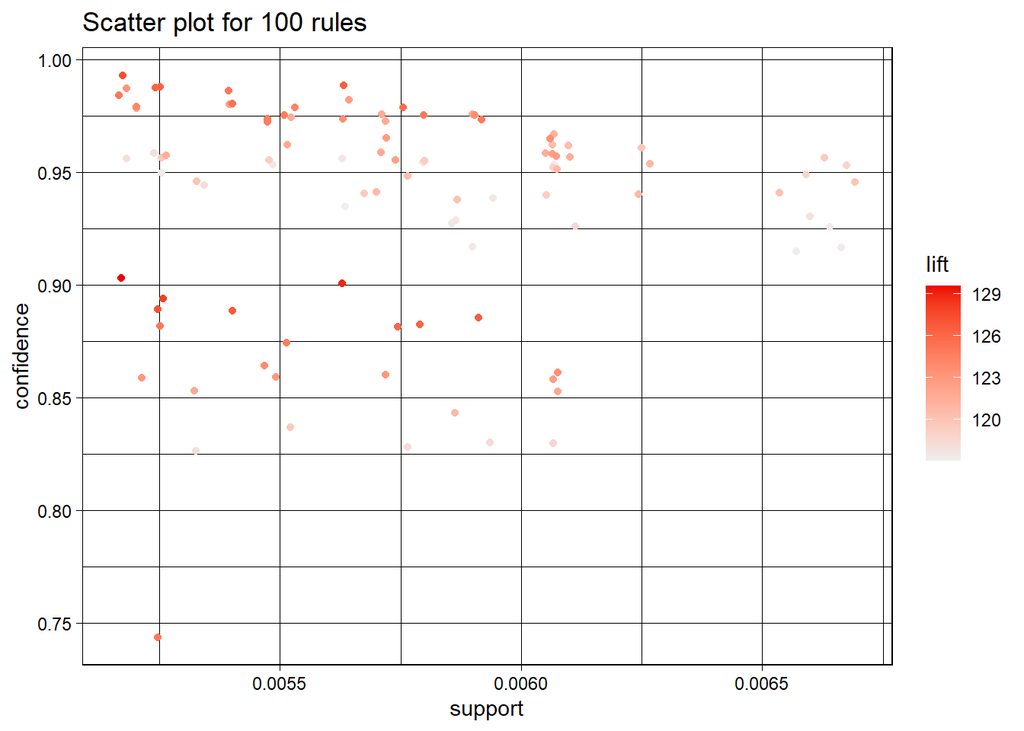

```r
# Visual Results using arulesViz (maximum 100 data points)
plot(rules, limit = 100)
```

## Steps 6-7 (Association Rules Mining): Interpret the results

The association rules mining model was able to predict several one-item high-confidence associations with high lift metrics. For example, if an ecommerce customer has the item “ELEPHANT” in their cart, it is almost guaranteed that they will also have a “BIRTHDAY CARD” item in their cart due to a confidence of 1.

Overall, the association rules model for the ecommerce dataset is a strong prescriber for shopping transactions.

#———— Resources ————# https://archive.ics.uci.edu/ml/datasets/Online+Shoppers+Purchasing+Intention+Dataset https://www.kaggle.com/iamprateek/store-transaction-data/version/1 https://www.kaggle.com/carrie1/ecommerce-data https://towardsdatascience.com/understanding-k-means-clustering-in-machine-learning-6a6e67336aa1 https://www.gatevidyalay.com/tag/disadvantages-of-k-means-clustering/ https://towardsdatascience.com/association-rule-mining-be4122fc1793 http://ijcsit.com/docs/Volume%205/vol5issue02/ijcsit20140502307.pdf https://uc-r.github.io/kmeans_clustering#kmeans https://www.datanovia.com/en/lessons/data-preparation-and-r-packages-for-cluster-analysis/ https://www.statology.org/remove-outliers-r/